# City-traffic-M: congestion and volume on 18 October 2024

The saved city-traffic-M visualization contains 720 roads on 2024-10-18. Its 96 fifteen-minute frames cover the day from 00:00 to 24:00; the last frame starts at 23:45. The default maps show 13:30, the original peak-congestion selection. The two trends cover all saved frames.

## Source and data preparation

The metadata identifies `mightyneghbor/city-traffic-benchmarks`, version 4. Upstream files are `city-traffic-M-raw-static-features.parquet`, `city-traffic-M-raw-volume.parquet` and `city-traffic-M-raw-speed.parquet`. The saved map consists of `city_traffic_M_osm_congestion_sample.html` and its companion JS and JSON files.

Data preparation validates the JSON literal assigned to `window.CITY_TRAFFIC_OSM_SAMPLE`, then wraps its original text in the reporting schema. The segment order, geometry, frame metrics and aggregate summaries are preserved. The companion JSON contains the same payload.

```r
source_js <- 'city_traffic_M_osm_congestion_sample.js'
source_lines <- readLines(source_js, warn=FALSE, encoding='UTF-8')
pattern <- '^\\s*window\\.CITY_TRAFFIC_OSM_SAMPLE\\s*=\\s*'
payload <- sub(';\\s*$', '', sub(pattern, '',
               grep(pattern, source_lines, value=TRUE)))
stopifnot(length(payload)==1L, jsonlite::validate(payload))
provenance <- jsonlite::toJSON(list(
  source_html=sub('\\.js$','.html',basename(source_js)),
  source_js=basename(source_js), source_md5=unname(tools::md5sum(source_js))),
  auto_unbox=TRUE)
artifact <- paste0('{"schema_version":1,"source":"metropolis","provenance":',
                   provenance,',"payload":{"data":',payload,'}}')
output_file <- 'data/metropolis-real.json.gz'
stopifnot(!file.exists(output_file))
dir.create(dirname(output_file), recursive=TRUE, showWarnings=FALSE)
con <- gzfile(output_file, 'wt')
tryCatch(writeLines(artifact, con, useBytes=TRUE), finally=close(con))
```

Preparation is separate from rendering. The report reads the saved file `data/metropolis-real.json.gz`.

The bundled `bdynets_0.1.0.tar.gz` supplies the version 0.1.0 source package, including its license. The report setup and `run.R` use an installed package when available; otherwise they install the bundled source into a temporary library for that R session. The package depends on `magrittr` in addition to standard R libraries. R Markdown rendering uses `jsonlite`, `rmarkdown`, `knitr` and Pandoc. The preparation code creates its output directory and refuses to overwrite an existing dataset.

The original generator, `build_city_traffic_osm_congestion_sample.py`, performs the following processing:

| Stage | Saved construction |
| --- | --- |
| Road selection | Selects 720 roads with nonzero volume using volume ranking and a 34 by 22 spatial grid. |
| Day selection | Selects the highest-volume eligible day with at least 288 five-minute records. |
| Temporal aggregation | Averages three five-minute observations into each fifteen-minute frame, interpolates in both directions, then fills remaining missing values with zero. |
| Speed reference | Uses each road’s whole-period 90th percentile of nonzero speed. |
| Payload | Saves road arrays, display scales and frame summaries; speed and volume have two decimal places and congestion three. |

## Saved fields

```r
x <- read_traffic_data(params$dataset)
meta <- x$data$metadata
stopifnot(x$source=='metropolis', !isTRUE(meta$synthetic),
          meta$sampleDay=='2024-10-18', length(x$data$frames)==96L,
          meta$frameIntervalMinutes==15L,
          x$data$frames[[1]]$time=='2024-10-18 00:00',
          x$data$frames[[96]]$time=='2024-10-18 23:45')
knitr::kable(data.frame(roads=length(x$data$segments), frames=length(x$data$frames),
                       minutes_per_frame=meta$frameIntervalMinutes))
```

| roads | frames | minutes_per_frame |
| --- | --- | --- |
| 720 | 96 | 15 |

| Field | Definition |
| --- | --- |
| `segments` | Road IDs, endpoint coordinates, static attributes, speed reference and maximum volume. |
| `frames[].volume`, `speed` | Saved road-level fifteen-minute averages. |
| `frames[].congestion` | Descriptive road-level index between zero and one. |
| `congestionMean`, `meanVolume` | Saved means for the whole frame. |
| `meanSpeed`, `active` | Mean speed over positive-volume roads, and the number of those roads. |
| `metadata` | Source, day, aggregation rule, display scale and peak frame. |

The saved metadata does not establish the formal measurement units, timezone or CRS. The source viewer labels speed as km/h. Interpreting saved x and y as longitude and latitude places the roads near Yekaterinburg; the metadata does not supply a publisher-confirmed city name.

## Maps and daily trends

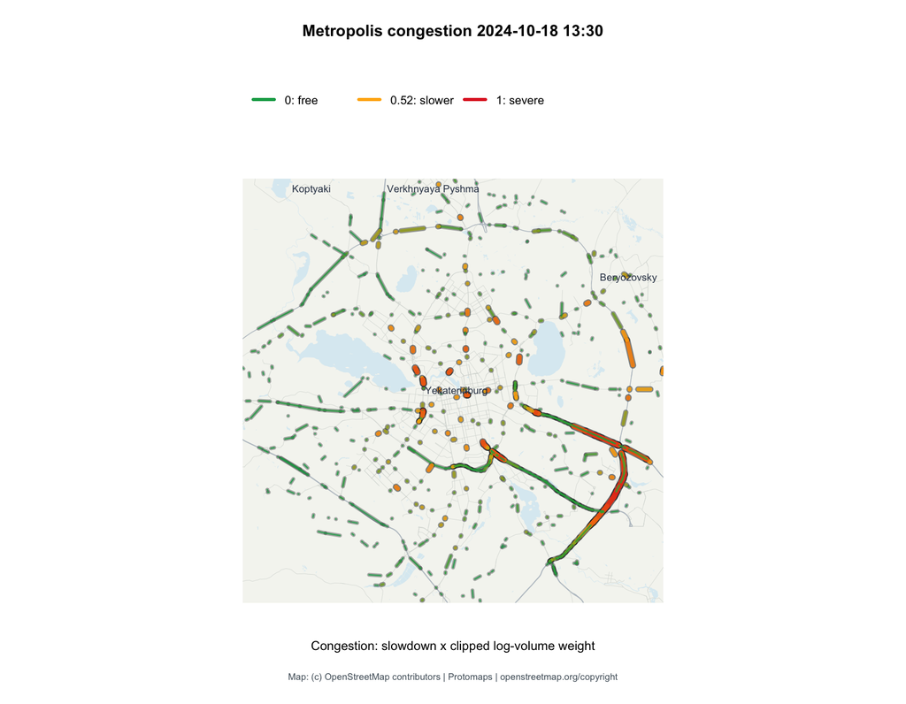

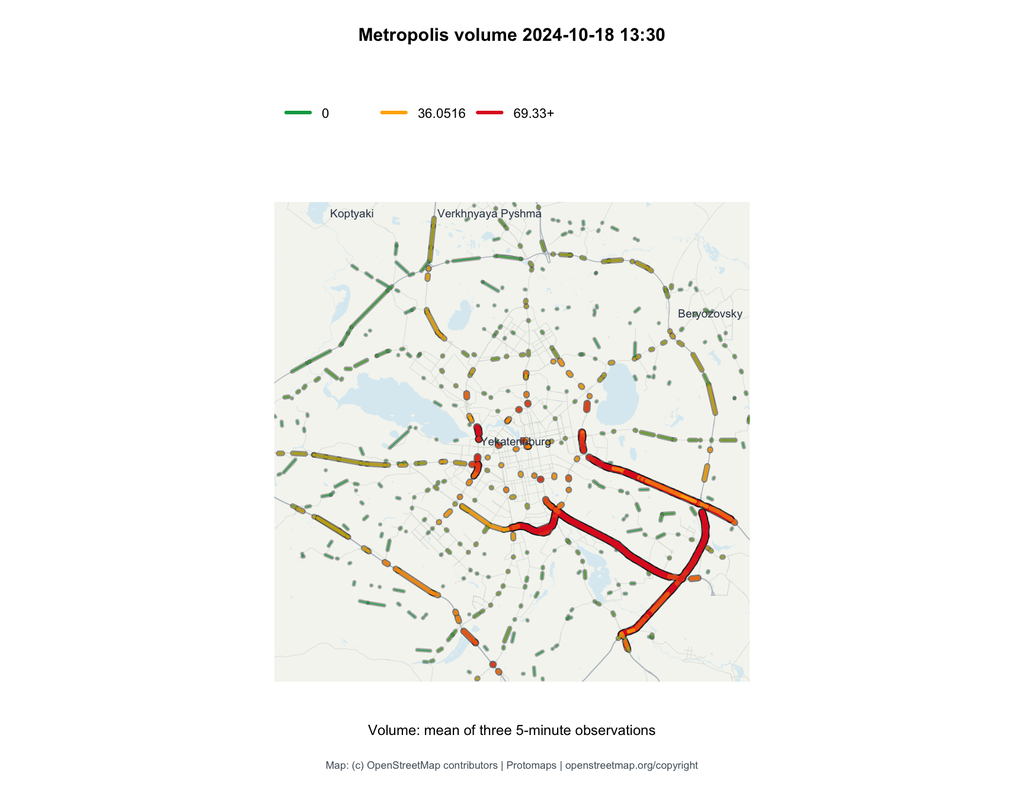

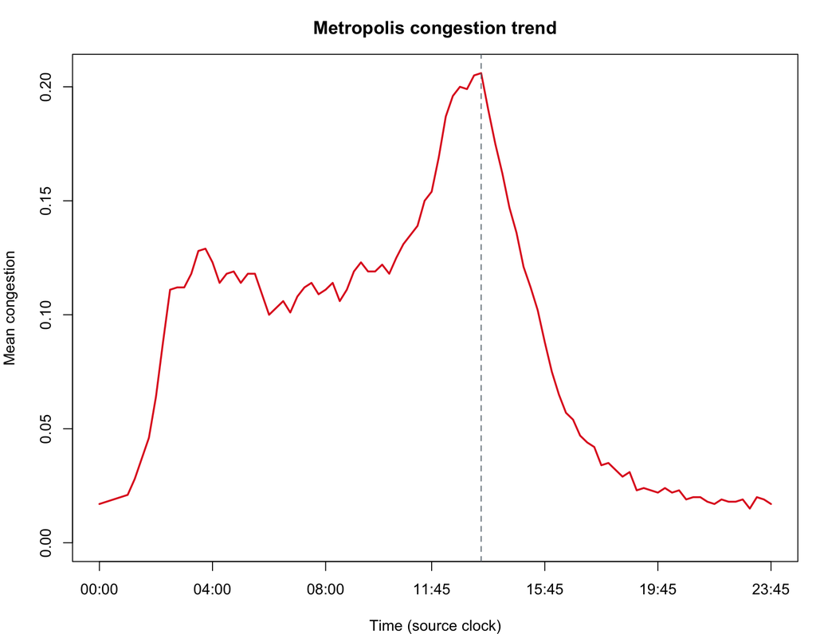

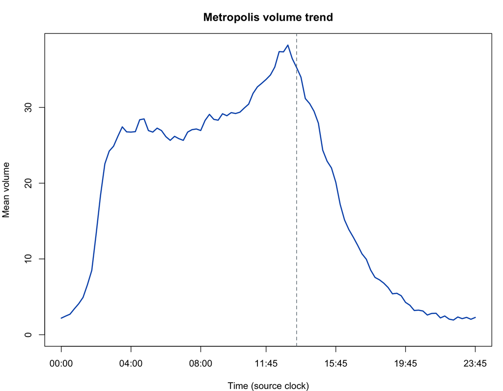

```r
figures <- traffic_osm_figures(params$dataset, 'metropolis',
                          time_index=params$time_index)
```

R frame 55 corresponds to JavaScript frame 54 and 13:30. The source selects this frame by total congestion. The congestion map uses the saved index; the volume map divides volume by the saved daily 95th percentile, 69.33, and clips the display scale to one. Both use a green, amber and red palette, with different quantities behind their colors. Static widths follow the source scaling and dark road casings.

The source congestion index combines nonnegative slowdown and a clipped log-volume weight:

```
congestion = clip(1 - speed / road_p90_speed, 0, 1)
             * clip(log1p(volume) / log1p(day_volume_p95), 0, 1)
```

The generator handles nonfinite intermediate values before saving. The report reads the saved congestion array rather than recomputing it from rounded speed and volume. Daily trends also read saved `congestionMean` and `meanVolume` summaries. The dashed line marks the selected frame.

Geometry uses Web Mercator for display. OSM supplies the original viewer’s background context; it does not enter the congestion calculation or establish network adjacency. These static panels contain the saved data layers over cached OSM-derived roads and water.

## Selected-frame statistics

```r
selected_frame <- x$data$frames[[params$time_index]]
statistics <- unlist(selected_frame[c('congestionMean','congestionP95',
                                     'meanSpeed','meanVolume','active')])
knitr::kable(data.frame(statistic=names(statistics), value=unname(statistics)))
```

| statistic | value |
| --- | --- |
| congestionMean | 0.206 |
| congestionP95 | 0.766 |
| meanSpeed | 49.340 |
| meanVolume | 35.260 |
| active | 632.000 |

The selected frame starts at 2024-10-18 13:30. `congestionMean` and `congestionP95` summarize the saved road congestion index. `meanVolume` is the saved mean across all selected roads; `meanSpeed` is the saved mean over roads with positive volume. `active` counts those positive-volume roads. These values come from the original frame summary rather than a recalculation from rounded road arrays. The displayed means are 0.206 for congestion, 35.26 for volume and 49.34 for speed, with 632 active roads.

## Offline geographic context

`osm-figures.R` draws the saved traffic frames over `data/osm-basemap.json.gz`. `download_osm.py` records the cache preparation: zoom-11 `roads`, `water` and `places` layers from the Protomaps archive dated 20 October 2026, covering the saved map bounds with a 0.02-degree margin. The cache contains the source URL, retrieval time, individual tile hashes and a checksum of the extracted geometry. Preparation depends on Python packages `requests`, `pmtiles` and `mapbox-vector-tile`; rendering reads the local cache without network requests.

The background is a generalized contemporary OSM extract. It supplies spatial context without changing traffic geometry, values, colors or connectivity. Available English place labels are thinned for readability. The basemap is not a reconstruction of the road network on the traffic observation date. Map data: [OpenStreetMap contributors](https://www.openstreetmap.org/copyright), via [Protomaps](https://docs.protomaps.com/basemaps/downloads), ODbL Produced Work.

## Frame selection and export

The `time_index` parameter covers R indices 1 through 96. Frame 33 starts at 08:00. The plotting workflow also provides individual maps, trends and exports:

```r
plot_traffic_osm(traffic_frame(x, time_index=33L, metric='volume'),
                 read_osm_basemap())
plot(traffic_trend(x, metric='congestion', time_index=33L))
traffic_osm_figures(params$dataset, 'metropolis', time_index=33L,
                output_dir='output/metropolis-0800')
```

Exports contain four PDF and PNG figures and source records. The HTML embeds all four panels. Dependencies are `bdynets`, `jsonlite`, `rmarkdown` and `knitr`, with Pandoc for HTML conversion.

## Interpretation

Volume ranking and spatial thinning determine the displayed roads, so the trends describe this selected set. Interpolation and zero filling conceal raw missingness. The whole-period speed reference includes observations outside the displayed day and can leak future information into prediction. Individual vehicle paths and validated directed adjacency are absent from this payload. Congestion-source attribution depends on those additional data and an explicit analysis model.